# SDS - project

Matteo Migliarini

2023-06-28

# Data

The data consists in matrix $X$ of $45 \times 11$ observations, where each $X_{ij}$ is either an approval or a rejection of the $i$th person (rater) of the $j$th pair of glasses (items).

Some of these datapoints are missing.

Below a graphical rappresentation of the dataset.

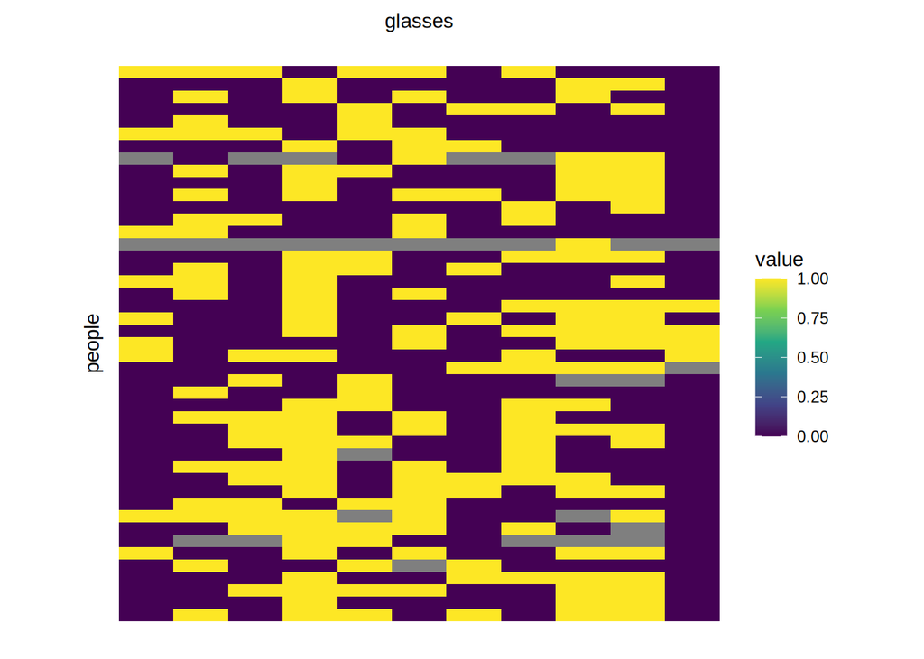

## Modelling Assumptions

- each item has an intrisic property of “quality”, we’ll model this for each item with the parameter $\psi_j$, where an higher value means higher quality.
- each person judges the objects and may be more or less strict in their judgements, we’ll model this with the parameter $tau_i$, where a lower value means a strciter judge.
- the probability that the $i$-th person will rate the $j$-th pair of glasses positevely will be called $\theta_{ij}$.
- $\theta_{ij}$ is a monotonic increasing in both $\psi_j$ and $tau_i$.

## Goals

The Goal of this analysis is to find which rater is the strictest one, and which pair of glasses is the best one.

# Jags

We’ll use the software JAGS and its `r` interface to perform simulation and sampling.

## Independent Betas

We model each $\psi_j$ and $\tau_i$ as Beta distributed random variables, independent from each other. In this model they represent the marginal probability of an item to be approved (independently from the rater) and vice-versa.

Than the probability of approval of an item $j$ from the rater $i$ is the average:
$$\theta_{ij} = \frac{\psi_j +
\tau_i}{2}$$

Note that we model the priors to be weakly centralized Beta distributions, instead of flat ones. This is because we make some kind of “assumption of mediocrity”, where we assume that most items and people will be in the middle.

### Simulation

Finally we can run the simulation, in order to check for convergence later we set different starting points for the parameters.

```r
jags.betas$BUGSoutput$DIC
```

```
## [1] 607.3446
```

### Results

#### $\theta$ grid

We then visualize the medians of the $\theta_{ij}$ parameters.

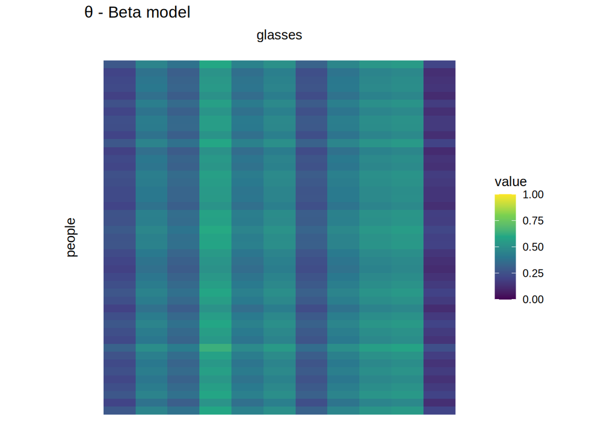

We notice how the model is able to capture many of the patterns that we saw in the data, such as the 4th item (column) being brighter than all others, and also the 11th being the darkest.

#### $\psi$ Confidence Intervals

Then we plot can look at the confidence intervals for the obtained parameters:

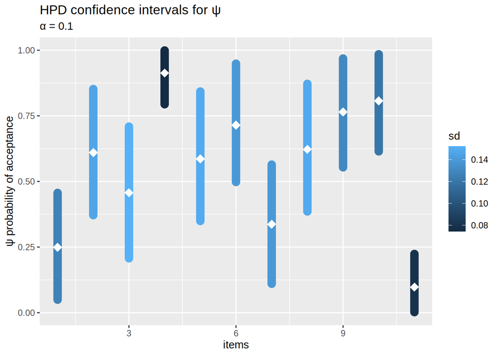

We note how the first, 7th and last (11th) $\psi$ are the lowest ones, while the 4th is especially higher than the others.

#### $\tau$ Confidence Intervals

When doing the same kind of analysis for the people’s strictness instead we don’t get results as clear as for the items.

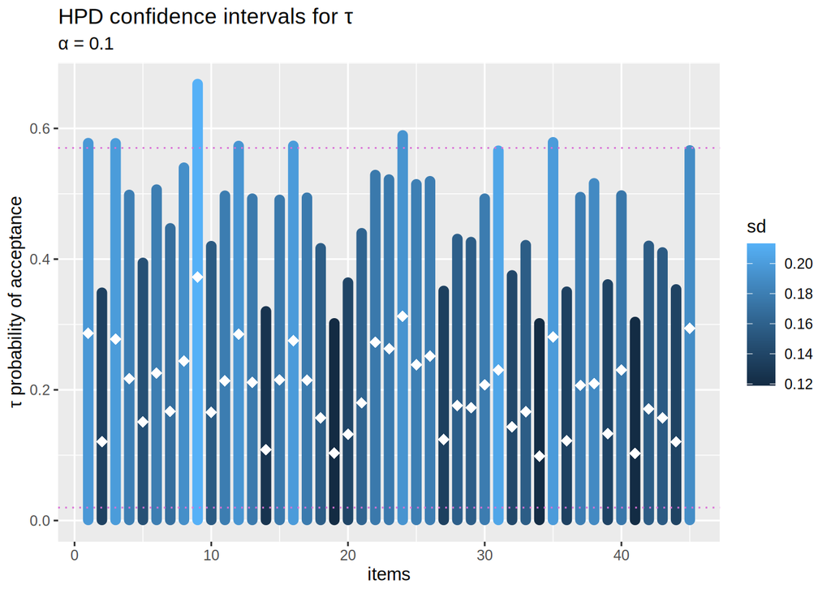

We can see that some confidence intervals are more lowered centered (as for rater #19 and #34), while some others are more higher centered (as for rater #9), but most of the confidence intervals are very large, and all of them overlap significantly with each other, meaning that maybe they aren’t very significant.

### $\tau$ importance

In order to assess if the $\tau$ parameters are actually useful we can compare the likelihood of the data given the model that we just fitted against the likelihood of the data where the $\tau$ parameters are just the mean of all taus: $\tau_u = mean_i \ \tau_i$.

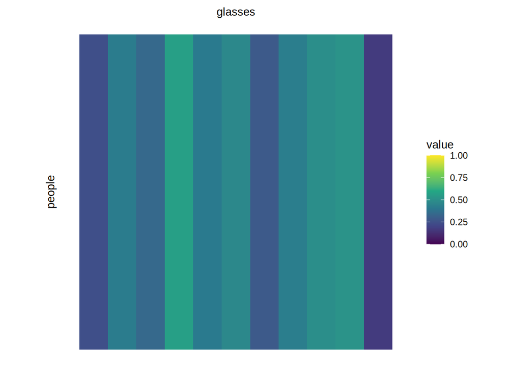

The likelihoods are different, but not so much: in fact the computed Bayes Factor is very little, and according to standard interpretation of the $BF$ this is a very weak evidence of actual performance difference among these models.

```
## [1] 2.827282
```

So we can conclude that modelling the $\tau$ parameters separately or as a single entity is almost the same.

### Comments on model

This model is quite simple and naive, being one of the first thing that came to my mind. So I also tried some variations:

- **Multivariate Beta** priors: all the $\psi_j$ and $\tau_i$ are correlated among themselves. The distribution was obtained through a gaussian copula, but the results were very unsatisfying since with this many parameters the model had a wild variance. Also I believe it didn’t make a lot of sense to assume a correlation among the raters strictness.
- **Non-hyerachical model**: all the $\psi_j$ and $\tau_i$ are independent beta distribution with no common hyperparameter. As expected this model performs worse, since the in this way the simulation cannot leverage on the shared properties of the parameters.
- Forced **symmetric Beta** distribution: at the beginning I assumed that the parameters must’ve been symmetrical in the point 0.5, such that for the Beta distribution the shape and rate parameters would’ve been equal $\alpha=\beta$. This model turned out to perform worse than the current one.

## Rasch Model

The Item Response Analysis may turn useful for this dataset. Classical item response analysis models the “*difficulty*” of items in order to measure objectively the “*proficiency*” of people. In this case it’s a bit reversed because we model the “*strictness*” of raters in order to measure objectively the “*goodness*” of items (the glasses).

This time we model $\psi$ and $\tau$ with normal distributions and then we define:
$$\theta_{ij} = \sigma(\psi_i-\tau_j)$$
where $\sigma$ is the well-known logistic function.

In the context of Item Response Analysis this is a *1PL* model (Rasch) where we model with $\tau_i$ the difficulty of items ($b_i$) and with $\psi_j$ the proficiency of people ($\theta_j$).

Also this time we run the model with multiple starting points, so that we can check their rightful convergence later.

First we note that albeit more sophisticated this method doesn’t have a wildly different *DIC* score, and this is probably fault of the very small number of samples that we have.

```r
jags.rasch$BUGSoutput$DIC
```

```
## [1] 601.041
```

#### $\theta$ grid

When plotting the values of $\theta_{ij}$ instead we notice how we are still able to capture the same patterns as before (high values for glasses#4 and low #11, etc…), but that this time the colors are much brighter than before. I believe this is due to the average between $\psi$ and $\tau$ that was done in the last model, that induced some kind of smoothing.

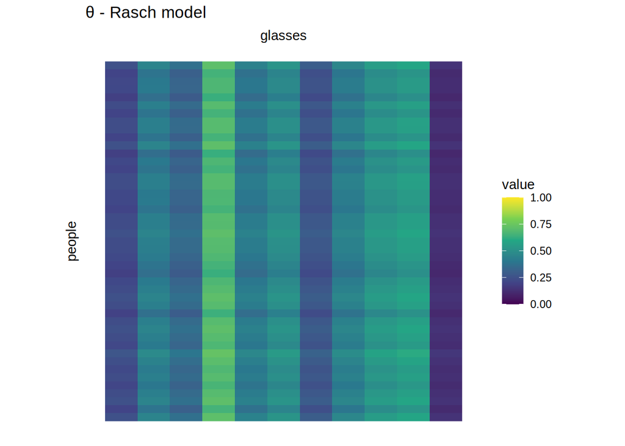

#### $\psi$ Confidence Intervals

Now the CI looks much more precise, and although the scale of the values lost some of its interpretability since it’s not anymore in $[0,1]$, we can clearly see that item #4 is easily the best one.

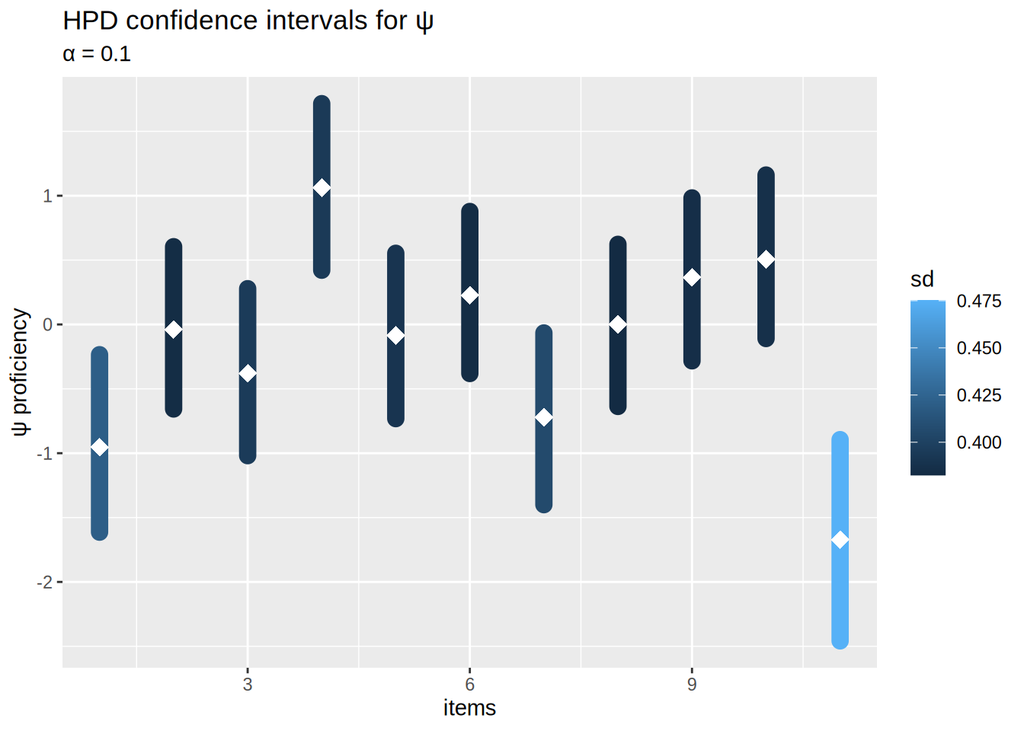

#### $\tau$ Confidence Intervals

Also here the difficulties almost look all the same (although one can clearly see that there’s a bit more variability now).

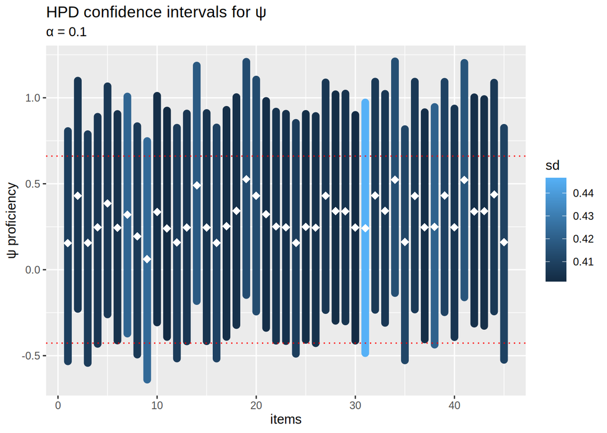

### Comments on model

This model is much more sophisticated than the other, and draws from the Item Response Analysis theory, but it’s still a simple enough model for the low amount of data that we got.

I also considered some variations of this model, but at the end decided against, preferring the simpler model. - **3PL** model: the full fledged model looked inadequate for this kind of data, due to the presence of the $c_i$ variable which stands for the probability of choosing the right choice by guessing, and this doesn’t make a lot of sense in the context of glasses being rated. - **2PL** model: I tried this model, but it performed poorly. The $a_i$ parameters which should account for the significance of each question (in our case the significance of a person) would’ve been nice to analyze, but the increase in the DIC was too significant.

# Model checks

We now want to check that our models actually converged and are in fact able to capture the nature of our data.

In order to do this we’ll use various diagnostic tools.

## Convergence Check

We note how it appears that the parameters converges together, even despite the different starting points.

### Traces

Here we can look at the initial trace of some of the parameters, first of the Beta model:

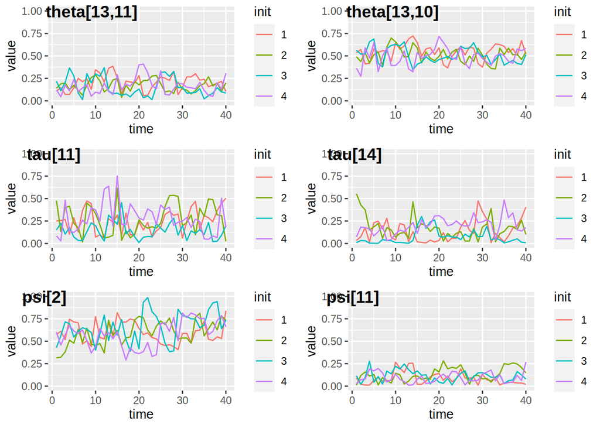

And then the Rasch model:

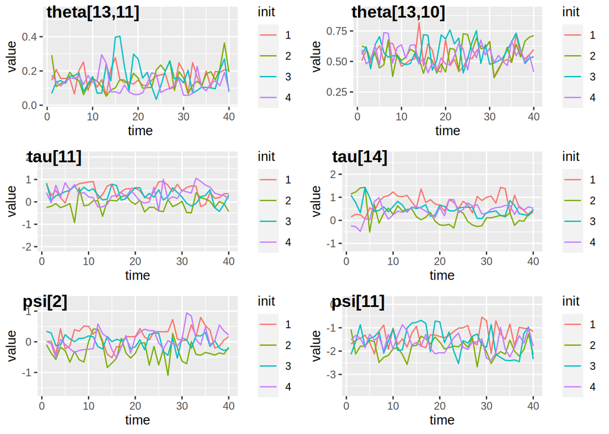

As a visual check we observe that overall the traces are crossing each other pretty often, meaning that they are all reaching the same convergence point. Later we’ll use the *R-hat* diagnostic parameter to formalize this visual check.

### Diagnosics

We now compute some diagnostic values for checking model convergence, In particular we’ll look at:

#### R-hat

This parameter compares agreement between different chains of the sampling, and it checks if the chains converge to the same point for each parameter. We then plot the *R-hat* for each of our 556 parameters.

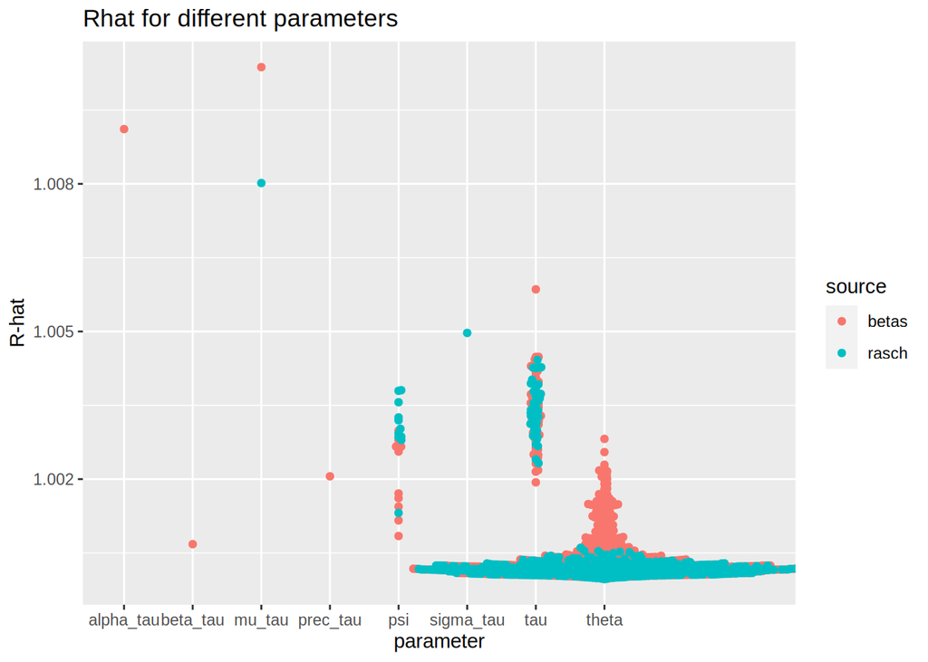

Since we observe that all parameters are well below the recommended 1.05 threshold we can conclude that the different chains of the model have converged to the same space.

We also note that the Rasch model tends to have a lower value of *R-hat*.

#### Effective Sample Size

This parameter tells us how many independent samples our simulation actually contains.

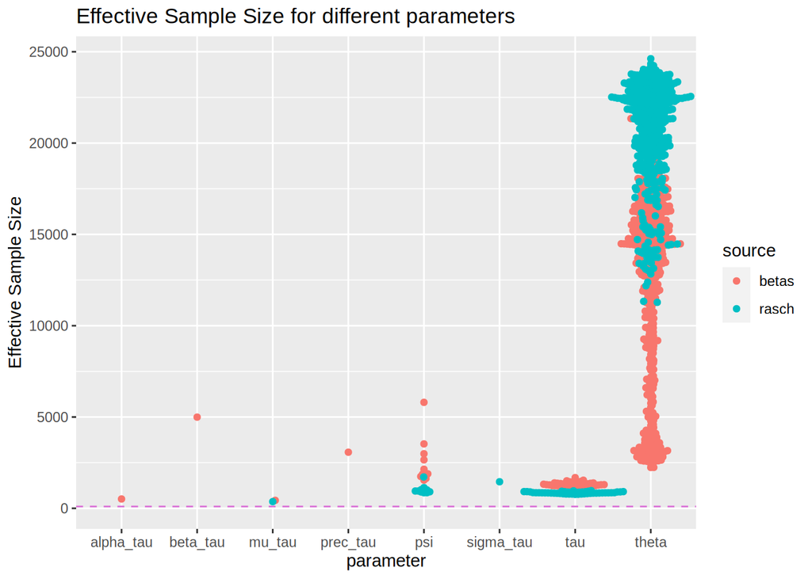

#### Autocorrelation

In order to understand how uch each sample is dependent on the previous one we can plot the Autocorrelation of the series, the faster this value converges to 0, the better it is.

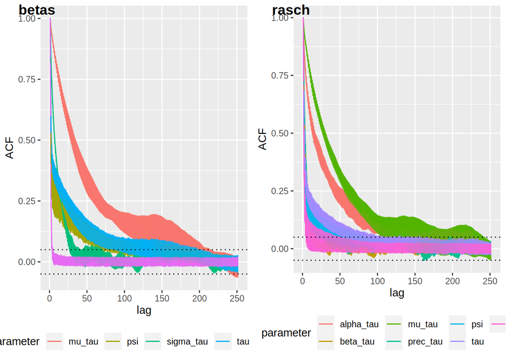

We note how both models tend to have a new uncorrelated sample every 200 or so iterations for the hyperpriors, and the hyperprior `mu_tau` seems a bit more problematic and autocorrelated than the others.

In the rest of the parameters it looks like that the Rasch model has less autocorrelation, and in particular the $\theta$ parameters go very fast towards 0.

## Model Comparison

### Binary Cross Entropy

We can borrow this tool to measure how distant are the obtained $\theta$ values from the data $X$, by computing the mean binary entropy:
$$-H_{ij} =X_{ij}log(\theta_{ij}) +
(1-X_{ij})log(1-\theta_{ij})$$
Finding that:

```
## [1] "Binary Cross Entropy - Betas: 0.625495858067746"
```

```
## [1] "Binary Cross Entropy - Rasch: 0.621773563093387"
```

### Posterior p-value Test

In order to measure the fitness of the model over the data we want to test how much likely is it to observe the same number of total approved pairs of glasses both in the real data and in the simulated (future) one. Of course in this process we also account for the imputed data, by removing them from the predictions.

In order to do this we compute the *posterior predictive p-value* of the test by:
$$ppp = P(\sum_{ij} \hat{X}_{ij} > \sum_{ij} X_{ij})$$
where $\hat{X}_{ij}$ is the predicted future data, usually called $y_{rep}$ or $y_{new}$.

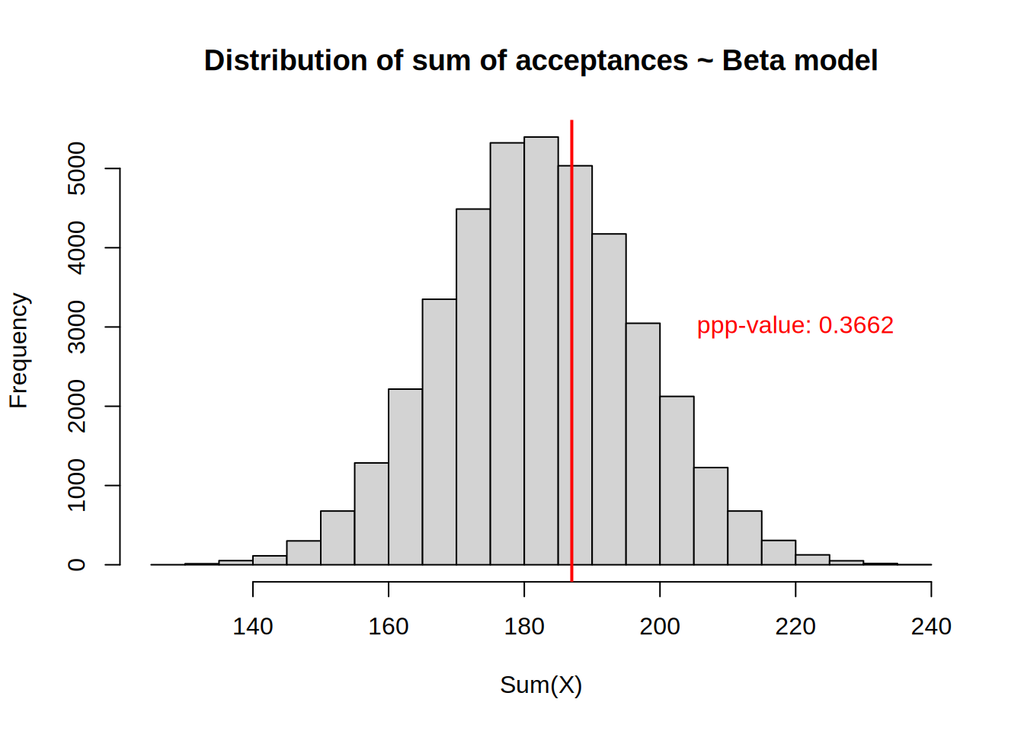

The score we obtain for the Beta model looks good enough, and it doesn’t look like there’s a lot of discrepancy between the median of the future data and the real one.

But if we repeat the test with the Rasch model, we see an almost perfect score! Very near to the ideal 0.5.

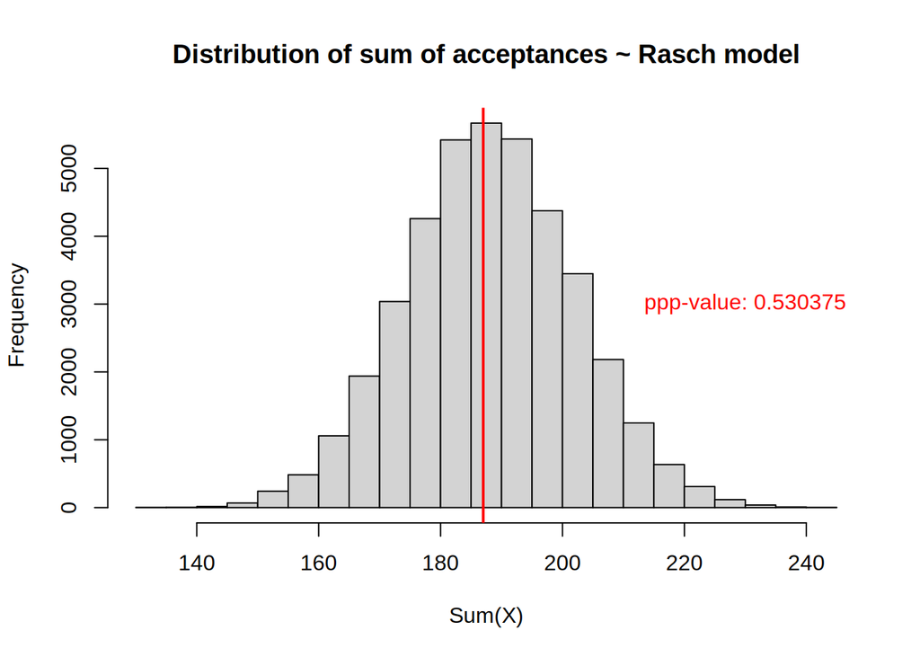

### Bayes Factor and model comparisom

We want to compare the two models and understand which one is fitting better the data. So as a first thing we compute the *Likelihoods* of the data given the models.

So now we can obtain the likelihood ratio between model beta and model rasch:

```
## [1] 0.175817
```

# Frequentist comparison

If we want to model this data with a frequentist approach, than we can assume that: - $\tau_i$ is the marginal probability that the $i$th rater will accept a pair of glasses; - $\psi_j$ is the marginal probability that the $j$th item will be accepted;

Then it’s pretty straightforward to prove that in this scenario:
$$\theta_{ij} = \frac{\tau_i \cdot \psi_j}{M}
; \ \ \ M = mean(X_{ij})$$

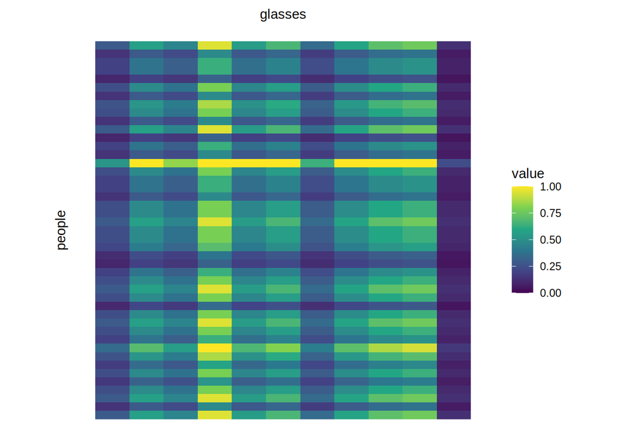

## ppp-value for Sum test

When repeating the sum test above with the frequentist model the results are quite good: better than the Beta model and only slightly worse than the Rasch model:

```
## [1] 0.4559
```

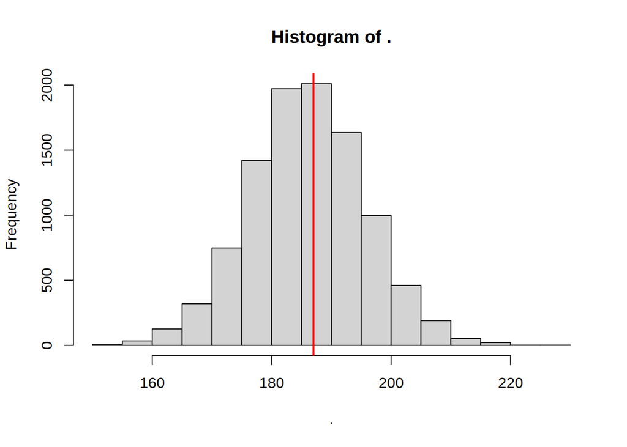